# Missed Connections Analysis

Karla Fettich

February 27, 2019

```r
# load all packages needed

rm(list = ls())
wd <- "/home/karla/Documents/RLadies/joys_fork/2019_datathon"

knitr::opts_chunk$set(echo = TRUE)
knitr::opts_knit$set(root.dir = wd)
library(rgdal)
library(raster)
library(tmap)
library(dplyr)
library(tidyr)
```

Here, I’ll try to understand what happens to the applications that don’t end up adopting. Are there some areas that submit an unusually high number of applications that don’t end up adopting?

## Load datasets

### Shape files

First, I’ll import the geo data for NJ and PA.

```r
# load geo data for nj & pa

nj <- shapefile("./Analyses/3_GIS/tl_2018_34_tract/tl_2018_34_tract.shp")
pa <- shapefile("./Analyses/3_GIS/tl_2018_42_tract/tl_2018_42_tract.shp")
pa_nj <- rbind(nj,pa)

summary(pa_nj)
```

```
## Object of class SpatialPolygonsDataFrame
## Coordinates:
##         min       max
## x -80.51985 -73.88506
## y  38.78866  42.51607
## Is projected: FALSE
## proj4string :
## [+proj=longlat +datum=NAD83 +no_defs +ellps=GRS80 +towgs84=0,0,0]
## Data attributes:
##    STATEFP            COUNTYFP           TRACTCE
##  Length:5228        Length:5228        Length:5228
##  Class :character   Class :character   Class :character
##  Mode  :character   Mode  :character   Mode  :character
##     GEOID               NAME             NAMELSAD
##  Length:5228        Length:5228        Length:5228
##  Class :character   Class :character   Class :character
##  Mode  :character   Mode  :character   Mode  :character
##     MTFCC             FUNCSTAT            ALAND
##  Length:5228        Length:5228        Length:5228
##  Class :character   Class :character   Class :character
##  Mode  :character   Mode  :character   Mode  :character
##     AWATER            INTPTLAT           INTPTLON
##  Length:5228        Length:5228        Length:5228
##  Class :character   Class :character   Class :character
##  Mode  :character   Mode  :character   Mode  :character
```

### Petpoint

Then, I’ll import PetPoint data. I am going to get rid of petpoint entries that don’t have a GEOID, because these are animals that either got euthanized, or got adopted outside the area of interest (PA and NJ).

```r
pp <- read.csv("./Data/petpoint.csv", stringsAsFactors = FALSE)
pp %>%
  filter(is.na(INTPTLON)) %>%
  group_by(outcome_type) %>%
  summarise(n = n())
```

```
## # A tibble: 6 x 2
##   outcome_type                 n
##   <chr>                    <int>
## 1 Admin Missing                1
## 2 Adoption                    60
## 3 Died                        83
## 4 Euthanasia                 103
## 5 Return to Owner/Guardian     4
## 6 Transfer Out                24
```

Everything except the “Adoption” line in this list is not informative for this analysis, so we can remove these. Let’s take a closer look at the Adoptions to make sure we’re not missing anything.

```r
pp %>%
  filter(is.na(INTPTLON), outcome_type=="Adoption") %>%
  group_by(outcome_state) %>%
  summarise(n = n())
```

```
## # A tibble: 13 x 2
##    outcome_state     n
##    <chr>         <int>
##  1 CO                1
##  2 CT                1
##  3 DE               15
##  4 FL                1
##  5 LA                1
##  6 MA                4
##  7 MD                9
##  8 NC                1
##  9 NY               20
## 10 OH                1
## 11 VA                1
## 12 VT                1
## 13 <NA>              4
```

All these adoptions are from states other than NJ and PA; also, the numbers are fairly low (except DE and NY, which are also low in comparison). So we can remove all these entries from analysis.

```r
pp <- pp[which(!is.na(pp$INTPTLON)),]
```

### Applications data

I’ll now load the applications data for both cats and dogs. We’ll also look at these datasets the same way as for petpoint - getting rid of applications that don’t have GEOIDs and assessing why those might be missing.

```r
dogs <- read.csv("./Data/dog_apps.csv", stringsAsFactors = FALSE)
dogs %>%
  filter(is.na(INTPTLON)) %>%
  group_by(State) %>%
  summarise(n = n())
```

```
## # A tibble: 7 x 2
##   State     n
##   <chr> <int>
## 1 CA        1
## 2 DE        8
## 3 GA        1
## 4 MD        7
## 5 MS        1
## 6 NY        2
## 7 PA        2
```

```r
dogs <- dogs[!is.na(dogs$INTPTLON),]  # get rid of geo NAs
```

We have 2 PA applicants that have missing geo data. Since it’s a low number, I will leave this as missing (can’t re-do the GEO matching so we’ll just have to run it as is). Everyone else is from states outside PA and NJ.

```r
cats <- read.csv("./Data/cat_apps.csv", stringsAsFactors = FALSE)
cats %>%
  filter(is.na(INTPTLON)) %>%
  group_by(State) %>%
  summarise(n = n())
```

```
## # A tibble: 10 x 2
##    State     n
##    <chr> <int>
##  1 CO        1
##  2 CT        1
##  3 DE        8
##  4 IL        1
##  5 LA        1
##  6 MA        4
##  7 MD        4
##  8 NC        1
##  9 NY        3
## 10 PA        7
```

```r
cats <- cats[!is.na(cats$INTPTLON),]  # get rid of geo NAs
```

For cats, we have 7 PA applicants with missing geo info. Ok.

### Cards data

```r
dogcards <- read.csv("./Data/dog_cards.csv", stringsAsFactors = FALSE)
dogs.pa_nj <- merge(dogs, dogcards, by.x="outcome_trello_id", by.y="id", all=TRUE)
dogs.pa_nj <- merge(dogs.pa_nj, pp, by="outcome_trello_id",all=TRUE)
dogs.pa_nj <- dogs.pa_nj[dogs.pa_nj$species=="Dog",]
```

```r
catcards <- read.csv("./Data/cat_cards.csv", stringsAsFactors = FALSE)
cats.pa_nj <- merge(cats, catcards, by.x="outcome_trello_id", by.y="id", all=TRUE)
cats.pa_nj <- merge(cats.pa_nj, pp, by="outcome_trello_id",all=TRUE)
cats.pa_nj <- cats.pa_nj[cats.pa_nj$species=="Cat",]
```

Before processing, let’s correct the time format on date of application submission, and date of outcome, and let’s also calculate the time difference between when an application was submitted and when the animal got adopted.

```r
dogs.pa_nj$outcome_date <- as.POSIXlt(dogs.pa_nj$outcome_date, format="%m/%d/%Y %H:%M %p")
dogs.pa_nj$date_submitted <- as.POSIXlt(dogs.pa_nj$date_submitted, format="%m/%d/%Y")
dogs.pa_nj$time_to_adoption <- as.numeric(difftime(dogs.pa_nj$outcome_date,
                                        dogs.pa_nj$date_submitted,
                                        units="days"))


cats.pa_nj$outcome_date <- as.POSIXlt(cats.pa_nj$outcome_date, format="%m/%d/%Y %H:%M %p")
cats.pa_nj$date_submitted <- as.POSIXlt(cats.pa_nj$date_submitted, format="%m/%d/%Y")
cats.pa_nj$time_to_adoption <- as.numeric(difftime(cats.pa_nj$outcome_date,
                                        cats.pa_nj$date_submitted,
                                        units="days"))
```

### Actions data

We’ll now load actions data, and mark the first and last event in the app processing timeline, and merge them with cards.

```r
dogactions <- read.csv("./Data/dog_actions.csv", stringsAsFactors = FALSE)

# find first and last event in app processing
dogactions$date <- strptime(dogactions$date, format="%Y-%m-%dT%H:%M:%SZ")
dogactions$startend <- NA
dogactions <- dogactions[order(dogactions$data.card.id,dogactions$date, decreasing = TRUE),]
dogactions$startend[!duplicated(dogactions$data.card.id)] <- "last"        # last event
dogactions <- dogactions[order(dogactions$data.card.id,dogactions$date),]
dogactions$startend[!duplicated(dogactions$data.card.id)] <- "first"        # first event

touchpoints <- dogactions[,c("data.card.id","type")] %>%
  group_by(data.card.id) %>%
  summarise(n=n())   # number of times somebody touched an application

dogactions$date <- as.character(dogactions$date)
dogactions.use <- reshape(dogactions[!is.na(dogactions$startend),c("data.card.id", "date","startend")], idvar = "data.card.id", timevar = "startend", direction = "wide")
dogactions.use <- merge(dogactions.use, touchpoints, by="data.card.id")
dogactions.use$date.first <- as.POSIXlt(dogactions.use$date.first, origin="1970-01-01")
dogactions.use$date.last <- as.POSIXlt(dogactions.use$date.last, origin="1970-01-01")
dogactions.use$timetoprocess <- round(as.numeric(difftime(dogactions.use$date.last, dogactions.use$date.first, units="hours")), digits=2)   # calciulate how many hours it takes for staff to process an application

dogcards <- merge(dogcards, dogactions.use, by.x="id",by.y="data.card.id")
```

```r
catactions <- read.csv("./Data/cat_actions.csv", stringsAsFactors = FALSE)

# find first and last event in app processing
catactions$date <- strptime(catactions$date, format="%Y-%m-%dT%H:%M:%SZ")
catactions$startend <- NA
catactions <- catactions[order(catactions$data.card.id,catactions$date, decreasing = TRUE),]
catactions$startend[!duplicated(catactions$data.card.id)] <- "last"        # last event
catactions <- catactions[order(catactions$data.card.id,catactions$date),]
catactions$startend[!duplicated(catactions$data.card.id)] <- "first"        # first event

touchpoints <- catactions[,c("data.card.id","type")] %>%
  group_by(data.card.id) %>%
  summarise(n=n())   # number of times somebody touched an application

catactions$date <- as.character(catactions$date)
catactions.use <- reshape(catactions[!is.na(catactions$startend),c("data.card.id", "date","startend")], idvar = "data.card.id", timevar = "startend", direction = "wide")
catactions.use <- merge(catactions.use, touchpoints, by="data.card.id")
catactions.use$date.first <- as.POSIXlt(catactions.use$date.first, origin="1970-01-01")
catactions.use$date.last <- as.POSIXlt(catactions.use$date.last, origin="1970-01-01")
catactions.use$timetoprocess <- round(as.numeric(difftime(catactions.use$date.last, catactions.use$date.first, units="hours")), digits=2)   # calculate how many hours it takes for staff to process an application

catcards <- merge(catcards, catactions.use, by.x="id",by.y="data.card.id")
```

### Census data

```r
hh <- read.csv("./Analyses/3_GIS/households_and_families/ACS_17_5YR_S1101_with_ann.csv", stringsAsFactors = FALSE)
hh$GEO.id2 <- as.numeric(hh$GEO.id2)
pp.hh <- merge(pp, hh, by.x="GEOID", by.y="GEO.id2")
pp.hh$HC01_EST_VC03 <- as.numeric(pp.hh$HC01_EST_VC03) # estimated average household size
pp.hh$HC01_EST_VC28 <- as.numeric(pp.hh$HC01_EST_VC28) # estimate of units in structure, where multiple units
pp.hh$HC01_EST_VC02 <- as.numeric(pp.hh$HC01_EST_VC02) # total households
```

## Analyses

I’m going to draw up some maps of missed connections.

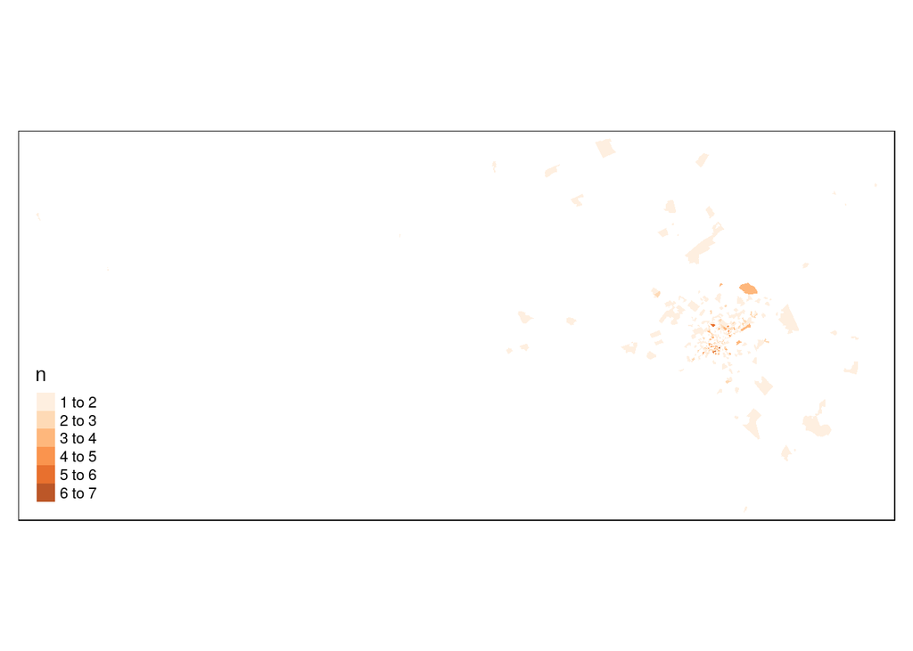

```r
pp <- pp[which(!is.na(pp$outcome_trello_id)),]
missed.connections <- dogs
missed.connections <- missed.connections[!missed.connections$outcome_trello_id %in% pp$outcome_trello_id,]

missed.connections <- missed.connections[,c("outcome_trello_id","GEOID")]
missed.connections.loc <- missed.connections[,c("GEOID","outcome_trello_id")] %>%
  group_by(GEOID) %>%
  summarise(n=n())
missed.connections.loc.spatial <-
  sp::merge(x = pa_nj, y =missed.connections.loc, by = "GEOID")
missed.connections.loc.spatial <- missed.connections.loc.spatial[which(!is.na(missed.connections.loc.spatial$n)), ]
tm_basemap("OpenStreetMap.BlackAndWhite") +
  tm_shape(missed.connections.loc.spatial) +
  tm_fill("n", palette = "Oranges", alpha=0.85)
```

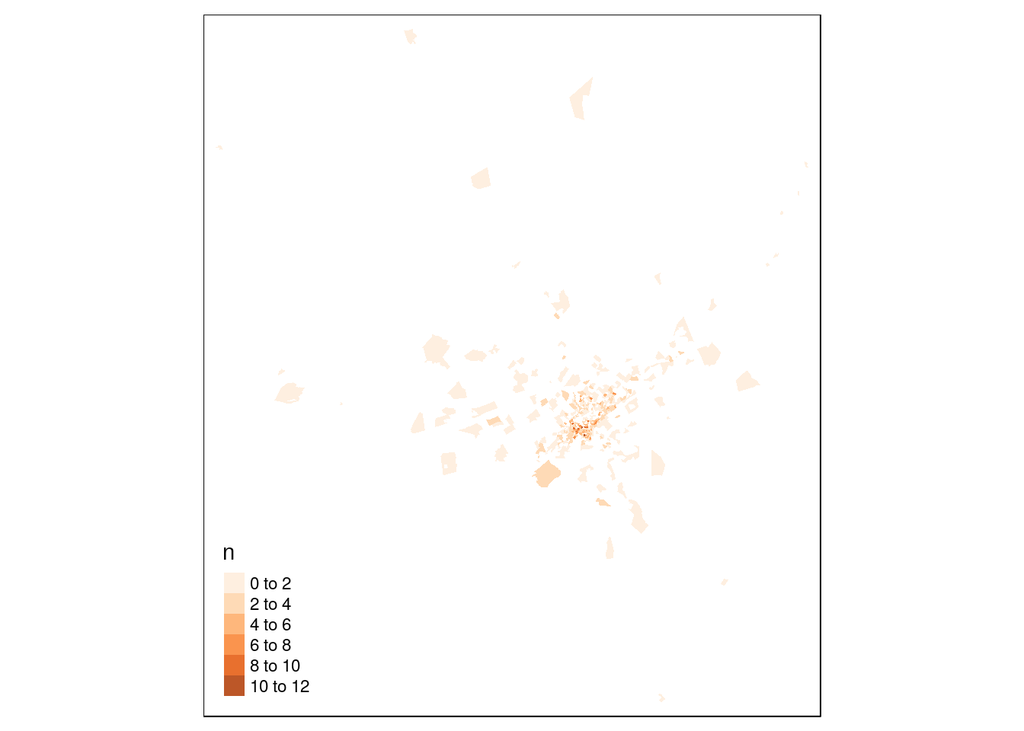

```r
# cats

missed.connections <- cats
missed.connections <- missed.connections[!missed.connections$outcome_trello_id %in% pp$outcome_trello_id,]

missed.connections <- missed.connections[,c("outcome_trello_id","GEOID")]
missed.connections.loc <- missed.connections[,c("GEOID","outcome_trello_id")] %>%
  group_by(GEOID) %>%
  summarise(n=n())
missed.connections.loc.spatial <-
  sp::merge(x = pa_nj, y =missed.connections.loc, by = "GEOID")
missed.connections.loc.spatial <- missed.connections.loc.spatial[which(!is.na(missed.connections.loc.spatial$n)), ]
tm_basemap("OpenStreetMap.BlackAndWhite") +
  tm_shape(missed.connections.loc.spatial) +
  tm_fill("n", palette = "Oranges", alpha=0.85)
```